# EDRM 718 Sp21: Exercise Set D

Geophrey O. Odero

21 February, 2021

**Directions:** *Complete this assignment in an R notebook. Make sure to number each item, but it is optional for you to copy the prompt for the item. Make sure that your notebook is neat and organized and that all your code chunks run without error, even after clearing the environment. Include both the exercise set letter and your name in your notebook filename. When you are finished, push your repository to GitHub. (Four points per item unless stated otherwise.)*

Question #1). **Write a script that (a) loads the Mount Juniper Elementary data into a data frame, (b) checks the score column to determine if there are missing data, and (c) prints either there are no missing data or there are missing data, depending on which of these is true.**

```r
# (a) Load data--------------

Mt_Juniper_data<- read.csv("C:/Jeff/Github/Edrm718Sp21/Data/Mount Juniper Elementary Data.csv")
```

```r
#(b) and (c)

score<-Mt_Juniper_data$Score

if (NA%in%score){
  print ("TRUE")
} else {

  print ("FALSE")
 }
```

```
[1] "TRUE"
```

Question #2). **In Exercise Set C, you wrote a script to determine whether you could infer a difference in scores for the different grades at Mount Juniper Elementary. Copy that script to this notebook, then add lines to your script to store your ANOVA or t test results in an object. Examine these results and correctly print “Statistically significant” or “Not statistically significant.” Use $\alpha= 0.05$. (Note: Avoid showing a warning message. If you need help, head to the Research Café.) (10 points)**

```r
# Lets run a anova-test

#Mt_Juniper$Grade <- factor(Mt_Juniper$Grade,
                          # labels = c("Third", "Fourth", "Fifth"))
Mt_Juniper_data$Grade <- factor(Mt_Juniper_data$Grade,
                           labels = c("Third", "Fourth", "Fifth"))

# here we store anova results in an object


aov_results<- summary(aov(Score ~ Grade, data =Mt_Juniper_data))


# p_value can be seen here on row#1 and column#5


p_value<- aov_results[[1]][[1, 5]]



if (p_value<0.05){
  print("Statistically Significant")
} else {
    print ("Not statistically significant")
  }
```

```
[1] "Not statistically significant"
```

Question #3.) **Add lines to your script to add a “Results” attribute to your object that contains the words “Statistically significant” or “Not statistically significant.” Use $\alpha= 0.05$. (Again, avoid a warning message.)**

```r
# Add "Results" attribute to aov_results

attr(aov_results,
     "Results") <- ifelse(p_value < .05,
                          "Statistically Significant",
                          "Not Statistically Significant")

# Lets check if the "Results" attribute does exist

attributes(aov_results)
```

```
$class
[1] "summary.aov" "listof"

$na.action
  8  16  17  30  34  41  46  53  73  74 106 119 137 155 175 176 177
  8  16  17  30  34  41  46  53  73  74 106 119 137 155 175 176 177
attr(,"class")
[1] "omit"

$Results
[1] "Not Statistically Significant"
```

Question #4). **Consider a population of normally distributed scores with a mean of 100 and a standard deviation of 15. Write a script to draw 1,000 random samples, each of size 40, from this population. Calculate and store each mean in a vector of means. Calculate the mean of the sample means. Determine the difference between the true mean of 100 and the mean of the sample means. What statistical characteristic of the mean does this illustrate? (10 points)**

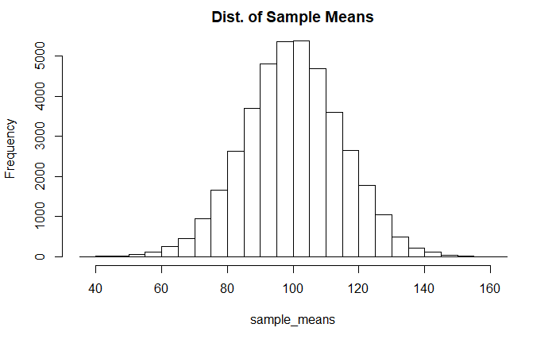

```r
# set seed every time you want to get a reproducible random result

set.seed(1222)
times<-1000
m<-matrix(nrow=times,ncol=40)
for (i in 1:times){
m[i,]=sample(rnorm(40,100, 15),replace=T)
}

# Lets visualize the distribution

hist(m,xlab="sample_means",main="Dist. of Sample Means",breaks=25)
```

```r
# Lets check the difference between true mean and mean of the samples

true_mean<-100
diff_means<-true_mean-mean(m)
diff_means
```

```
[1] -0.03705423
```

*The sample mean is an unbiased estimator of the population mean*.

Question #5). **Write a script that will count in your console pane from 0, in increments of 10, up to 1,000. Do three different versions of the script: (a) with a for loop, (b) with a while loop, and (c) with a repeat and break structure. (12 points)**

```r
#(a)  For loop

for (i in seq(0, 1000, 10))
  print(i)
```

```
[1] 0
[1] 10
[1] 20
[1] 30
[1] 40
[1] 50
[1] 60
[1] 70
[1] 80
[1] 90
[1] 100
[1] 110
[1] 120
[1] 130
[1] 140
```

[output cut: 86 more lines]

```r
#
```

```r
# (b)
count<-0
while (count<1001){
  print(count)
  count<-count+10
}
```

```
[1] 0
[1] 10
[1] 20
[1] 30
[1] 40
[1] 50
[1] 60
[1] 70
[1] 80
[1] 90
[1] 100
[1] 110
[1] 120
[1] 130
[1] 140
```

[output cut: 86 more lines]

```r
#(c)   repeat and break

x<-0
repeat {
  print (x)
  x= x + 10
  if (x == 1010){
    break
  }
}
```

```
[1] 0
[1] 10
[1] 20
[1] 30
[1] 40
[1] 50
[1] 60
[1] 70
[1] 80
[1] 90
[1] 100
[1] 110
[1] 120
[1] 130
[1] 140
```

[output cut: 86 more lines]

Question #6). **The Secret Code file contains a hidden message. Use nested for loops to reveal the message by pasting together the characters in every 8th position (i.e., positions 8, 16, 24, and 32) on all 23 rows. (15 points)**

```r
secret_code<- Secret_Code <- read.csv2("C:/Jeff/Github/Edrm718Sp21/Exercise Sets/Data/Secret_Code.csv",sep = ",",header = FALSE)

# Lets create an object called NULL


sep_code<-NULL

# Specifying the positions

secret_code <- secret_code[, c(8, 16, 24, 32)]


for (j in secret_code) {
  sep_code <- paste(sep_code, j, sep = "")

  secret_text<- NULL

  for (i in sep_code ) {
    secret_text<- paste(secret_text, i, sep = "")
  }
}

secret_text
```

```
[1] "Statistics is awesome, but it is even awesomer when you have R in your statistical toolbox!!"
```

Question #7). **Bootstrapping is a statistical method for making inferences based on repeated sampling from a sample of observed values. Write a script to construct a 90% confidence interval for the mean using bootstrapping by taking the following steps. (Note: There are bootstrapping functions and packages, but do not use these for this assignment. Instead, follow the steps below.) (25 points)**

a). *Load the Sample Data into an object. These data contain 30 scores selected at random from an unknown population. (I know the population, but you don’t!)*

```r
# load data-----------

sample_data<- read.csv("C:/Jeff/Github/Edrm718Sp21/Data/Sample Data .csv", sep="")
```

b). *Select and store 5,000 samples of size 30 that are sampled from the Sample Data with replacement. (Hint: Use the sample function.)*

```r
B<-5000
n<-nrow(sample_data)
boot_samples<-matrix(sample(sample_data$Score, size = B * n, replace = TRUE),
B, n)
```

c). *Calculate and store the mean of every sample. Collectively these means will be an estimate of the sampling distribution of the mean.*

```r
# Lets visualize the distribution
mean(boot_means)
```

[output not shown]

```
[1] 326.3424
```

d). *The 5th and 95th percentiles of the sampling distribution are the boundaries of a 90% confidence interval. Calculate these and report your interval.*

```r
# Find endpoints for 90%  bootstrap confidence intervals using percentiles

quantile(boot_means,c(0.05,0.95))
```

```
      5%      95%
308.8333 343.4683
```

**Doing a-d at once**

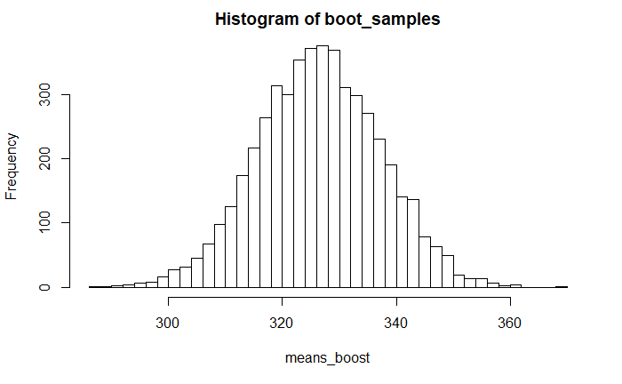

```r
set.seed(97338)
boot_samples<- rep(NA, 5000)
for(i in 1:5000){
    resample <- sample(sample_data$Score, size=30, replace=T)
    boot_samples[i] <- mean(resample)
}
hist(boot_samples,xlab="means_boost",breaks=50)
```

```r
quantile(boot_samples, c(0.05, 0.95)) # get 90% CI
```

```
      5%      95%
308.8000 343.9683
```